# tidyr

Lecture 07

Dr. Colin Rundel

[figure not shown]

# Reshaping data

## Wide -> Long

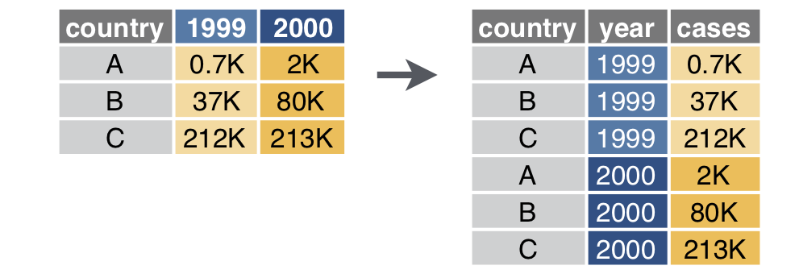

`pivot_longer` (previously `gather`)

From [Data tidying with tidyr](https://raw.githubusercontent.com/rstudio/cheatsheets/main/tidyr.pdf)

## Syntax

```r
(d = tibble::tribble(
  ~country, ~"1999",  ~"2000",
        "A", "0.7K",     "2K",
        "B",  "37K",    "80K",
        "C", "212K",   "213K"
))
```

```
# A tibble: 3 × 3
  country `1999` `2000`
  <chr>   <chr>  <chr>
1 A       0.7K   2K
2 B       37K    80K
3 C       212K   213K
```

```r
pivot_longer(
  d,
  cols = "1999":"2000",
  names_to = "year",
  values_to = "cases"
)
```

```
# A tibble: 6 × 3
  country year  cases
  <chr>   <chr> <chr>
1 A       1999  0.7K
2 A       2000  2K
3 B       1999  37K
4 B       2000  80K
5 C       1999  212K
6 C       2000  213K
```

## Long -> Wide

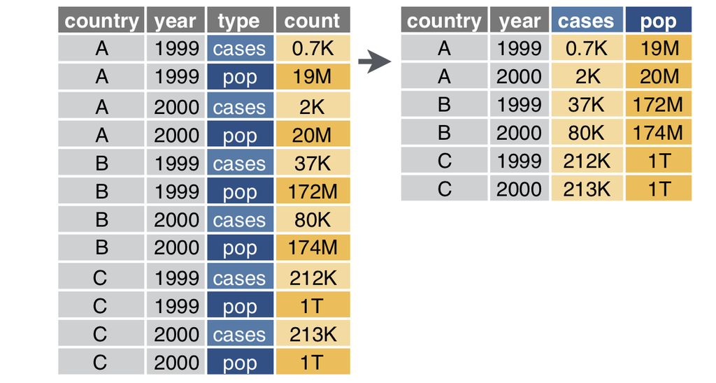

`pivot_wider` (previously `spread`)

From [Data tidying with tidyr](https://raw.githubusercontent.com/rstudio/cheatsheets/main/tidyr.pdf)

## Syntax

```r
( d = tibble::tribble(
    ~country, ~year,   ~type, ~count,
         "A",  1999, "cases", "0.7K",
         "A",  1999,   "pop",  "19M",
         "A",  2000, "cases",   "2K",
         "A",  2000,   "pop",  "20M",
         "B",  1999, "cases",  "37K",
         "B",  1999,   "pop", "172M",
         "B",  2000, "cases", " 80K",
         "B",  2000,   "pop", "174M",
         "C",  1999, "cases", "212K",
         "C",  1999,   "pop",   "1T",
         "C",  2000, "cases", "213K",
         "C",  2000,   "pop",   "1T"
  )
)
```

```
# A tibble: 12 × 4
   country  year type  count
   <chr>   <dbl> <chr> <chr>
 1 A        1999 cases "0.7K"
 2 A        1999 pop   "19M"
 3 A        2000 cases "2K"
 4 A        2000 pop   "20M"
 5 B        1999 cases "37K"
 6 B        1999 pop   "172M"
 7 B        2000 cases " 80K"
 8 B        2000 pop   "174M"
 9 C        1999 cases "212K"
10 C        1999 pop   "1T"
11 C        2000 cases "213K"
12 C        2000 pop   "1T"
```

```r
pivot_wider(
  d,
  id_cols = country:year,
  names_from = type,
  values_from = count
)
```

```
# A tibble: 6 × 4
  country  year cases  pop
  <chr>   <dbl> <chr>  <chr>
1 A        1999 "0.7K" 19M
2 A        2000 "2K"   20M
3 B        1999 "37K"  172M
4 B        2000 " 80K" 174M
5 C        1999 "212K" 1T
6 C        2000 "213K" 1T
```

## Exercise 1

The `palmerpenguin` package contains measurement data on various penguin species on islands near Palmer Station in Antarctica. The code below shows the # of each species measured on each of the three islands (missing island, penguin pairs implies that species does not occur on that island).

```r
palmerpenguins::penguins |>
  count(island, species)
```

```
# A tibble: 5 × 3
  island    species       n
  <fct>     <fct>     <int>
1 Biscoe    Adelie       44
2 Biscoe    Gentoo      124
3 Dream     Adelie       56
4 Dream     Chinstrap    68
5 Torgersen Adelie       52
```

Starting from these data construct a contingency table of counts for island (rows) by species (columns) using the pivot functions we’ve just discussed.

`05:00`

## Separate - wider

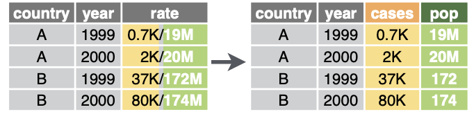

```r
separate_wider_delim(d, rate, delim = "/", names = c("cases", "pop"))
```

```
# A tibble: 6 × 4
  country  year cases pop
  <chr>   <dbl> <chr> <chr>
1 A        1999 0.7K  19M
2 A        2000 2K    20M
3 B        1999 37K   172M
4 B        2000 80K   174M
5 C        1999 212K  1T
6 C        2000 213K  1T
```

From [Data tidying with tidyr](https://raw.githubusercontent.com/rstudio/cheatsheets/main/tidyr.pdf)

## Separate - longer

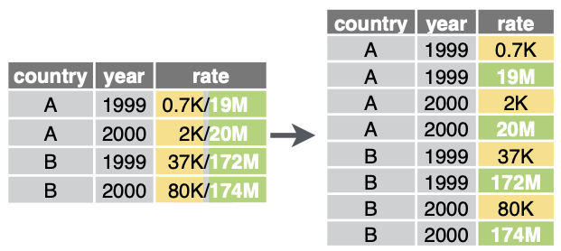

```r
separate_longer_delim(d, rate, delim = "/")
```

```
# A tibble: 12 × 3
   country  year rate
   <chr>   <dbl> <chr>
 1 A        1999 0.7K
 2 A        1999 19M
 3 A        2000 2K
 4 A        2000 20M
 5 B        1999 37K
 6 B        1999 172M
 7 B        2000 80K
 8 B        2000 174M
 9 C        1999 212K
10 C        1999 1T
11 C        2000 213K
12 C        2000 1T
```

From [Data tidying with tidyr](https://raw.githubusercontent.com/rstudio/cheatsheets/main/tidyr.pdf)

## Other separates

In previous versions of tidyr there was a single catch-all `separate()` function. This still exists and is available in the package but it is [**superseded**](https://lifecycle.r-lib.org/articles/stages.html).

Other helpful separate functions:

- `separate_longer_position()`
- `separate_wider_position()`
- `separate_wider_regex()`

## Unite

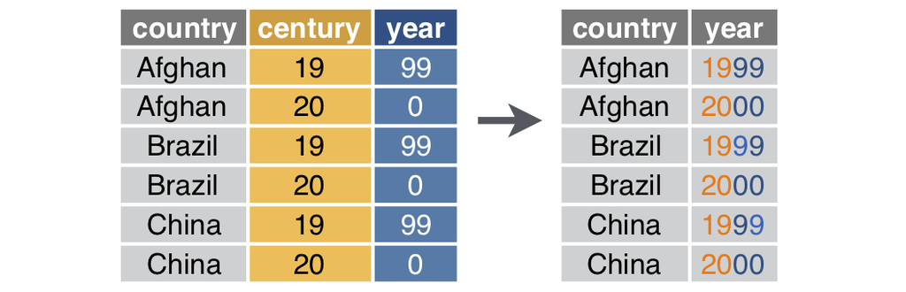

```r
unite(d, century, year, col = "year", sep = "")
```

```
# A tibble: 6 × 2
  country year
  <chr>   <chr>
1 Afghan  1999
2 Afghan  2000
3 Brazil  1999
4 Brazil  2000
5 China   1999
6 China   2000
```

From [Data tidying with tidyr](https://raw.githubusercontent.com/rstudio/cheatsheets/main/tidyr.pdf)

## Example 1 - tidy grades

Is the following data tidy?

```r
grades = tibble::tribble(
  ~name,   ~hw_1, ~hw_2, ~hw_3, ~hw_4, ~proj_1, ~proj_2,
  "Alice",    19,    19,    18,    20,      89,      95,
  "Bob",      18,    20,    18,    16,      77,      88,
  "Carol",    18,    20,    18,    17,      96,      99,
  "Dave",     19,    19,    18,    19,      86,      82
)
```

How would we calculate a final score based on the following formula,
$$\text{score} = 0.5\,\frac{\sum_i\text{hw}_i}{80} + 0.5\,\frac{\sum_j\text{proj}_j}{200}$$

## Semi-tidy approach

```r
grades |>
  mutate(
    hw_avg = (hw_1+hw_2+hw_3+hw_4)/4,
    proj_avg = (proj_1+proj_2)/2
  ) |>
  mutate(
    overall = 0.5*(proj_avg/100) + 0.5*(hw_avg/20)
  )
```

```
# A tibble: 4 × 10
  name   hw_1  hw_2  hw_3  hw_4 proj_1 proj_2 hw_avg proj_avg overall
  <chr> <dbl> <dbl> <dbl> <dbl>  <dbl>  <dbl>  <dbl>    <dbl>   <dbl>
1 Alice    19    19    18    20     89     95   19       92     0.935
2 Bob      18    20    18    16     77     88   18       82.5   0.862
3 Carol    18    20    18    17     96     99   18.2     97.5   0.944
4 Dave     19    19    18    19     86     82   18.8     84     0.889
```

## pivot_longer (Wide -> Long)

```r
tidyr::pivot_longer(
  grades,
  cols = hw_1:proj_2,
  names_to = "assignment",
  values_to = "score"
)
```

```
# A tibble: 24 × 3
   name  assignment score
   <chr> <chr>      <dbl>
 1 Alice hw_1          19
 2 Alice hw_2          19
 3 Alice hw_3          18
 4 Alice hw_4          20
 5 Alice proj_1        89
 6 Alice proj_2        95
 7 Bob   hw_1          18
 8 Bob   hw_2          20
 9 Bob   hw_3          18
10 Bob   hw_4          16
# ℹ 14 more rows
```

## Split type and id

```r
tidyr::pivot_longer(
  grades,
  cols = hw_1:proj_2,
  names_to = c("type", "id"),
  names_sep = "_",
  values_to = "score"
)
```

```
# A tibble: 24 × 4
   name  type  id    score
   <chr> <chr> <chr> <dbl>
 1 Alice hw    1        19
 2 Alice hw    2        19
 3 Alice hw    3        18
 4 Alice hw    4        20
 5 Alice proj  1        89
 6 Alice proj  2        95
 7 Bob   hw    1        18
 8 Bob   hw    2        20
 9 Bob   hw    3        18
10 Bob   hw    4        16
# ℹ 14 more rows
```

## Tidy approach?

```r
grades |>
  tidyr::pivot_longer(
    cols = hw_1:proj_2,
    names_to = c("type", "id"),
    names_sep = "_",
    values_to = "score"
  ) |>
  summarize(
    total = sum(score),
    .by = c(name, type)
  )
```

```
# A tibble: 8 × 3
  name  type  total
  <chr> <chr> <dbl>
1 Alice hw       76
2 Alice proj    184
3 Bob   hw       72
4 Bob   proj    165
5 Carol hw       73
6 Carol proj    195
7 Dave  hw       75
8 Dave  proj    168
```

## pivot_wider - (Long -> Wide)

```r
grades |>
  tidyr::pivot_longer(
    cols = hw_1:proj_2,
    names_to = c("type", "id"),
    names_sep = "_",
    values_to = "score"
  ) |>
  summarize(
    total = sum(score),
    .by = c(name, type)
  ) |>
  tidyr::pivot_wider(
    names_from = type,
    values_from = total
  )
```

```
# A tibble: 4 × 3
  name     hw  proj
  <chr> <dbl> <dbl>
1 Alice    76   184
2 Bob      72   165
3 Carol    73   195
4 Dave     75   168
```

## Wrapping up

```r
grades |>
  tidyr::pivot_longer(
    cols = hw_1:proj_2,
    names_to = c("type", "id"),
    names_sep = "_",
    values_to = "score"
  ) |>
  summarize(
    total = sum(score),
    .by = c(name, type)
  ) |>
  tidyr::pivot_wider(
    names_from = type,
    values_from = total
  ) |>
  mutate(
    score = 0.5*(hw/80) +
            0.5*(proj/200)
  )
```

```
# A tibble: 4 × 4
  name     hw  proj score
  <chr> <dbl> <dbl> <dbl>
1 Alice    76   184 0.935
2 Bob      72   165 0.862
3 Carol    73   195 0.944
4 Dave     75   168 0.889
```

# Rectangling

## Star Wars & repurrrsive

`repurrrsive` is a package that contains a number of interesting example data sets that are stored in a hierarchical format. Many come from web-based APIs which provide results as JSON.

```r
str(repurrrsive::sw_people)
```

```
List of 87
 $ :List of 16
  ..$ name      : chr "Luke Skywalker"
  ..$ height    : chr "172"
  ..$ mass      : chr "77"
  ..$ hair_color: chr "blond"
  ..$ skin_color: chr "fair"
  ..$ eye_color : chr "blue"
  ..$ birth_year: chr "19BBY"
  ..$ gender    : chr "male"
  ..$ homeworld : chr "http://swapi.co/api/planets/1/"
  ..$ films     : chr [1:5] "http://swapi.co/api/films/6/" "http://swapi.co/api/films/3/" "http://swapi.co/api/films/2/" "http://swapi.co/api/films/1/" ...
  ..$ species   : chr "http://swapi.co/api/species/1/"
  ..$ vehicles  : chr [1:2] "http://swapi.co/api/vehicles/14/" "http://swapi.co/api/vehicles/30/"
  ..$ starships : chr [1:2] "http://swapi.co/api/starships/12/" "http://swapi.co/api/starships/22/"
  ..$ created   : chr "2014-12-09T13:50:51.644000Z"
  ..$ edited    : chr "2014-12-20T21:17:56.891000Z"
  ..$ url       : chr "http://swapi.co/api/people/1/"
 $ :List of 14
  ..$ name      : chr "C-3PO"
  ..$ height    : chr "167"
  ..$ mass      : chr "75"
  ..$ hair_color: chr "n/a"
  ..$ skin_color: chr "gold"
  ..$ eye_color : chr "yellow"
  ..$ birth_year: chr "112BBY"
  ..$ gender    : chr "n/a"
  ..$ homeworld : chr "http://swapi.co/api/planets/1/"
  ..$ films     : chr [1:6] "http://swapi.co/api/films/5/" "http://swapi.co/api/films/4/" "http://swapi.co/api/films/6/" "http://swapi.co/api/films/3/" ...
  ..$ species   : chr "http://swapi.co/api/species/2/"
  ..$ created   : chr "2014-12-10T15:10:51.357000Z"
  ..$ edited    : chr "2014-12-20T21:17:50.309000Z"
  ..$ url       : chr "http://swapi.co/api/people/2/"
 $ :List of 14
  ..$ name      : chr "R2-D2"
  ..$ height    : chr "96"
  ..$ mass      : chr "32"
  ..$ hair_color: chr "n/a"
  ..$ skin_color: chr "white, blue"
  ..$ eye_color : chr "red"
```

[output cut: 1277 more lines]

```
  ..$ name      : chr "Padmé Amidala"
  ..$ height    : chr "165"
  ..$ mass      : chr "45"
  ..$ hair_color: chr "brown"
  ..$ skin_color: chr "light"
  ..$ eye_color : chr "brown"
  ..$ birth_year: chr "46BBY"
  ..$ gender    : chr "female"
  ..$ homeworld : chr "http://swapi.co/api/planets/8/"
  ..$ films     : chr [1:3] "http://swapi.co/api/films/5/" "http://swapi.co/api/films/4/" "http://swapi.co/api/films/6/"
  ..$ species   : chr "http://swapi.co/api/species/1/"
  ..$ starships : chr [1:3] "http://swapi.co/api/starships/49/" "http://swapi.co/api/starships/64/" "http://swapi.co/api/starships/39/"
  ..$ created   : chr "2014-12-19T17:28:26.926000Z"
  ..$ edited    : chr "2016-04-20T17:06:31.502555Z"
  ..$ url       : chr "http://swapi.co/api/people/35/"
```

## RStudio data viewer

```r
View(repurrrsive::sw_people)
```

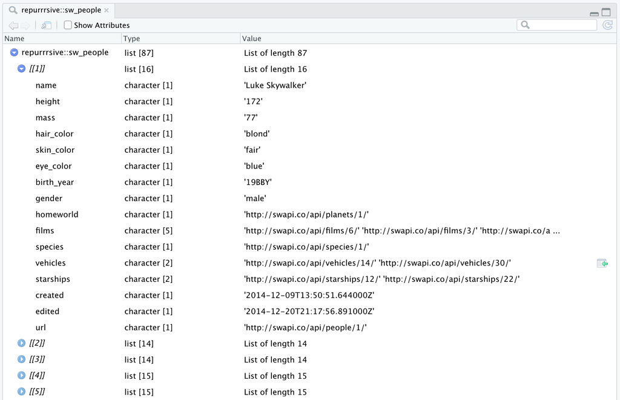

## Tidy data from nested lists

In addition to `pivot_*` the `tidyr` package also has a number of functions that are designed to aid in the tidying of hierarchical / nested data.

For today we will be discussing the `unnest_longer()`, and `unnest_wider()` functions and next week we will see `hoist()`.

Much like the functions we saw last time in `dplyr`, these functions are designed to work with data frames (which may seem odd at first).

## List columns

We can make `sw_people` into a data frame by treating the original list as a single column in a data frame.

```r
(sw_df = tibble::tibble(
  people = repurrrsive::sw_people
))
```

```
# A tibble: 87 × 1
   people
   <list>
 1 <named list [16]>
 2 <named list [14]>
 3 <named list [14]>
 4 <named list [15]>
 5 <named list [15]>
 6 <named list [14]>
 7 <named list [14]>
 8 <named list [14]>
 9 <named list [15]>
10 <named list [16]>
# ℹ 77 more rows
```

```r
as.data.frame(sw_df) |> head()
```

```
                                                                                                                                                                                                                                                                                                            …
1 Luke Skywalker, 172, 77, blond, fair, blue, 19BBY, male, http://swapi.co/api/planets/1/, http://swapi.co/api/films/6/, http://swapi.co/api/films/3/, http://swapi.co/api/films/2/, http://swapi.co/api/films/1/, http://swapi.co/api/films/7/, http://swapi.co/api/species/1/, http://swapi.co/api/vehicle…
2                                                                                                                      C-3PO, 167, 75, n/a, gold, yellow, 112BBY, n/a, http://swapi.co/api/planets/1/, http://swapi.co/api/films/5/, http://swapi.co/api/films/4/, http://swapi.co/api/films/6/, http://swap…
3                                                                                      R2-D2, 96, 32, n/a, white, blue, red, 33BBY, n/a, http://swapi.co/api/planets/8/, http://swapi.co/api/films/5/, http://swapi.co/api/films/4/, http://swapi.co/api/films/6/, http://swapi.co/api/films/3/, http://swap…
4                                                                                                                                    Darth Vader, 202, 136, none, white, yellow, 41.9BBY, male, http://swapi.co/api/planets/1/, http://swapi.co/api/films/6/, http://swapi.co/api/films/3/, http://swapi.co/…
5                                                                                                        Leia Organa, 150, 49, brown, light, brown, 19BBY, female, http://swapi.co/api/planets/2/, http://swapi.co/api/films/6/, http://swapi.co/api/films/3/, http://swapi.co/api/films/2/, http://swapi.co…
6                                                                                                                                                                                                    Owen Lars, 178, 120, brown, grey, light, blue, 52BBY, male, http://swapi.co/api/planets/1/, http://swap…
```

## Unnesting

```r
sw_df |>
  unnest_wider(people)
```

```
# A tibble: 87 × 16
   name           height mass  hair_color skin_color eye_color birth_year gender
   <chr>          <chr>  <chr> <chr>      <chr>      <chr>     <chr>      <chr>
 1 Luke Skywalker 172    77    blond      fair       blue      19BBY      male
 2 C-3PO          167    75    n/a        gold       yellow    112BBY     n/a
 3 R2-D2          96     32    n/a        white, bl… red       33BBY      n/a
 4 Darth Vader    202    136   none       white      yellow    41.9BBY    male
 5 Leia Organa    150    49    brown      light      brown     19BBY      female
 6 Owen Lars      178    120   brown, gr… light      blue      52BBY      male
 7 Beru Whitesun… 165    75    brown      light      blue      47BBY      female
 8 R5-D4          97     32    n/a        white, red red       unknown    n/a
 9 Biggs Darklig… 183    84    black      light      brown     24BBY      male
10 Obi-Wan Kenobi 182    77    auburn, w… fair       blue-gray 57BBY      male
# ℹ 77 more rows
# ℹ 8 more variables: homeworld <chr>, films <list>, species <chr>,
#   vehicles <list>, starships <list>, created <chr>, edited <chr>, url <chr>
```

## Unnesting - column types

```r
sw_df |>
  unnest_wider(people) |>
  pull(height)
```

```
 [1] "172"     "167"     "96"      "202"     "150"     "178"     "165"
 [8] "97"      "183"     "182"     "188"     "180"     "228"     "180"
[15] "173"     "175"     "170"     "180"     "66"      "170"     "183"
[22] "200"     "190"     "177"     "175"     "180"     "150"     "unknown"
[29] "88"      "160"     "193"     "191"     "170"     "196"     "224"
[36] "206"     "183"     "137"     "112"     "183"     "163"     "175"
[43] "180"     "178"     "94"      "122"     "163"     "188"     "198"
[50] "196"     "171"     "184"     "188"     "264"     "188"     "196"
[57] "185"     "157"     "183"     "183"     "170"     "166"     "165"
[64] "193"     "191"     "183"     "168"     "198"     "229"     "213"
[71] "167"     "79"      "96"      "193"     "191"     "178"     "216"
[78] "234"     "188"     "178"     "206"     "unknown" "unknown" "unknown"
[85] "unknown" "unknown" "165"
```

## More list columns

```r
sw_df |>
  unnest_wider(people) |>
  select(name, starships)
```

```
# A tibble: 87 × 2
   name               starships
   <chr>              <list>
 1 Luke Skywalker     <chr [2]>
 2 C-3PO              <NULL>
 3 R2-D2              <NULL>
 4 Darth Vader        <chr [1]>
 5 Leia Organa        <NULL>
 6 Owen Lars          <NULL>
 7 Beru Whitesun lars <NULL>
 8 R5-D4              <NULL>
 9 Biggs Darklighter  <chr [1]>
10 Obi-Wan Kenobi     <chr [5]>
# ℹ 77 more rows
```

```r
sw_df |>
  unnest_wider(people) |>
  select(name, starships) |>
  pull(starships) |>
  str()
```

```
List of 87
 $ : chr [1:2] "http://swapi.co/api/starships/12/" "http://swapi.co/api/starships/22/"
 $ : NULL
 $ : NULL
 $ : chr "http://swapi.co/api/starships/13/"
 $ : NULL
 $ : NULL
 $ : NULL
 $ : NULL
 $ : chr "http://swapi.co/api/starships/12/"
 $ : chr [1:5] "http://swapi.co/api/starships/48/" "http://swapi.co/api/starships/59/" "http://swapi.co/api/starships/64/" "http://swapi.co/api/starships/65/" ...
 $ : chr [1:3] "http://swapi.co/api/starships/59/" "http://swapi.co/api/starships/65/" "http://swapi.co/api/starships/39/"
 $ : NULL
 $ : chr [1:2] "http://swapi.co/api/starships/10/" "http://swapi.co/api/starships/22/"
 $ : chr [1:2] "http://swapi.co/api/starships/10/" "http://swapi.co/api/starships/22/"
```

[output cut: 73 more lines]

## Unnest Longer

```r
unnest_wider(sw_df, people) |>
  select(name, starships) |>
  unnest_longer(starships)
```

```
# A tibble: 31 × 2
   name              starships
   <chr>             <chr>
 1 Luke Skywalker    http://swapi.co/api/starships/12/
 2 Luke Skywalker    http://swapi.co/api/starships/22/
 3 Darth Vader       http://swapi.co/api/starships/13/
 4 Biggs Darklighter http://swapi.co/api/starships/12/
 5 Obi-Wan Kenobi    http://swapi.co/api/starships/48/
 6 Obi-Wan Kenobi    http://swapi.co/api/starships/59/
 7 Obi-Wan Kenobi    http://swapi.co/api/starships/64/
 8 Obi-Wan Kenobi    http://swapi.co/api/starships/65/
 9 Obi-Wan Kenobi    http://swapi.co/api/starships/74/
10 Anakin Skywalker  http://swapi.co/api/starships/59/
# ℹ 21 more rows
```

## `sw_starships`

```r
(ships = tibble(ships = repurrrsive::sw_starships) |>
   unnest_wider(ships) |>
   select(ship = name, url)
)
```

```
# A tibble: 37 × 2
   ship                          url
   <chr>                         <chr>
 1 Sentinel-class landing craft  http://swapi.co/api/starships/5/
 2 Death Star                    http://swapi.co/api/starships/9/
 3 Millennium Falcon             http://swapi.co/api/starships/10/
 4 Y-wing                        http://swapi.co/api/starships/11/
 5 X-wing                        http://swapi.co/api/starships/12/
 6 TIE Advanced x1               http://swapi.co/api/starships/13/
 7 Executor                      http://swapi.co/api/starships/15/
 8 Slave 1                       http://swapi.co/api/starships/21/
 9 Imperial shuttle              http://swapi.co/api/starships/22/
10 EF76 Nebulon-B escort frigate http://swapi.co/api/starships/23/
# ℹ 27 more rows
```

## General advice

- If there is a consistent set of entries (usually named) in the list column, use `unnest_wider()`
- If there are different numbers of entries (often unnamed) in the list column, use `unnest_longer()`
- Never use just `unnest()` - it can be inconsistent depending on input data
- Think about if you need all the data or not - `unnest_*()` are not always the best choice (more on the `hoist()` alternative next time)

# Joins

[figure not shown]

## Joins (left)

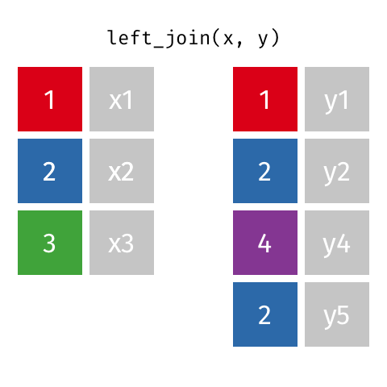

From gadenbuie/tidyexplain

## Joins (right)

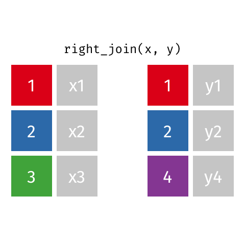

From gadenbuie/tidyexplain

## Joins (full / outer)

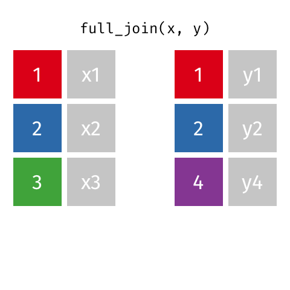

From gadenbuie/tidyexplain

## Joins (inner)

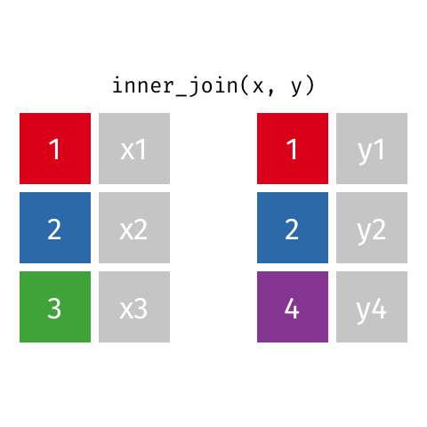

From gadenbuie/tidyexplain

## join `by`

By default dplyr’s join functions will join based on intersecting column names between the two data frames.

To specify the columns to join by (or to handle non-matching names) pass in a character vector of column names (or a named character vector where the names match the left data frame and the values match the right).

Recently more advanced joins have been implemented using the `join_by()` construct which allows for: equality, inequality, rolling, overlap, and cross joins. See `?join_by` for details.

## Joining people and starships

```r
sw_df |>
  unnest_wider(people) |>
  select(name, starships) |>
  unnest_longer(starships) |>
  left_join(ships, by = c("starships" = "url"))
```

```
# A tibble: 31 × 3
   name              starships                         ship
   <chr>             <chr>                             <chr>
 1 Luke Skywalker    http://swapi.co/api/starships/12/ X-wing
 2 Luke Skywalker    http://swapi.co/api/starships/22/ Imperial shuttle
 3 Darth Vader       http://swapi.co/api/starships/13/ TIE Advanced x1
 4 Biggs Darklighter http://swapi.co/api/starships/12/ X-wing
 5 Obi-Wan Kenobi    http://swapi.co/api/starships/48/ Jedi starfighter
 6 Obi-Wan Kenobi    http://swapi.co/api/starships/59/ Trade Federation cruiser
 7 Obi-Wan Kenobi    http://swapi.co/api/starships/64/ Naboo star skiff
 8 Obi-Wan Kenobi    http://swapi.co/api/starships/65/ Jedi Interceptor
 9 Obi-Wan Kenobi    http://swapi.co/api/starships/74/ Belbullab-22 starfighter
10 Anakin Skywalker  http://swapi.co/api/starships/59/ Trade Federation cruiser
# ℹ 21 more rows
```

## Putting it together

```r
sw_df |>
  unnest_wider(people) |>
  select(name, starships) |>
  unnest_longer(starships) |>
  inner_join(ships, by = c("starships" = "url")) |>
  select(-starships) |>
  group_by(name) |>
  summarize(ships = list(ship), .groups = "drop")
```

```
# A tibble: 20 × 2
   name              ships
   <chr>             <list>
 1 Anakin Skywalker  <chr [3]>
 2 Arvel Crynyd      <chr [1]>
 3 Biggs Darklighter <chr [1]>
 4 Boba Fett         <chr [1]>
 5 Chewbacca         <chr [2]>
 6 Darth Maul        <chr [1]>
 7 Darth Vader       <chr [1]>
 8 Gregar Typho      <chr [1]>
 9 Grievous          <chr [1]>
10 Han Solo          <chr [2]>
11 Jek Tono Porkins  <chr [1]>
12 Lando Calrissian  <chr [1]>
13 Luke Skywalker    <chr [2]>
14 Nien Nunb         <chr [1]>
15 Obi-Wan Kenobi    <chr [5]>
16 Padmé Amidala     <chr [3]>
17 Plo Koon          <chr [1]>
18 Poe Dameron       <chr [1]>
19 Ric Olié          <chr [1]>
20 Wedge Antilles    <chr [1]>
```

```r
sw_df |>
  unnest_wider(people) |>
  select(name, starships) |>
  unnest_longer(starships) |>
  inner_join(ships, by = c("starships" = "url")) |>
  select(-starships) |>
  group_by(name) |>
  summarize(ships = paste(ship, collapse = ", "), .groups = "drop")
```

```
# A tibble: 20 × 2
   name              ships
   <chr>             <chr>
 1 Anakin Skywalker  Trade Federation cruiser, Jedi Interceptor, Naboo fighter
 2 Arvel Crynyd      A-wing
 3 Biggs Darklighter X-wing
 4 Boba Fett         Slave 1
 5 Chewbacca         Millennium Falcon, Imperial shuttle
 6 Darth Maul        Scimitar
 7 Darth Vader       TIE Advanced x1
 8 Gregar Typho      Naboo fighter
 9 Grievous          Belbullab-22 starfighter
10 Han Solo          Millennium Falcon, Imperial shuttle
11 Jek Tono Porkins  X-wing
12 Lando Calrissian  Millennium Falcon
13 Luke Skywalker    X-wing, Imperial shuttle
14 Nien Nunb         Millennium Falcon
15 Obi-Wan Kenobi    Jedi starfighter, Trade Federation cruiser, Naboo star ski…
16 Padmé Amidala     H-type Nubian yacht, Naboo star skiff, Naboo fighter
17 Plo Koon          Jedi starfighter
18 Poe Dameron       T-70 X-wing fighter
19 Ric Olié          Naboo Royal Starship
20 Wedge Antilles    X-wing
```

## Exercise 2

1. Which planet appeared in the most starwars film (according to the data in `sw_planets`)?
2. Which planet was the homeworld of the most characters in the starwars films?

`05:00`